# Postgres With R

How to connect and do R/SQL operations in Postgres database with R - name: Serdar Dindas url: https://serdardindas.netlify.app/

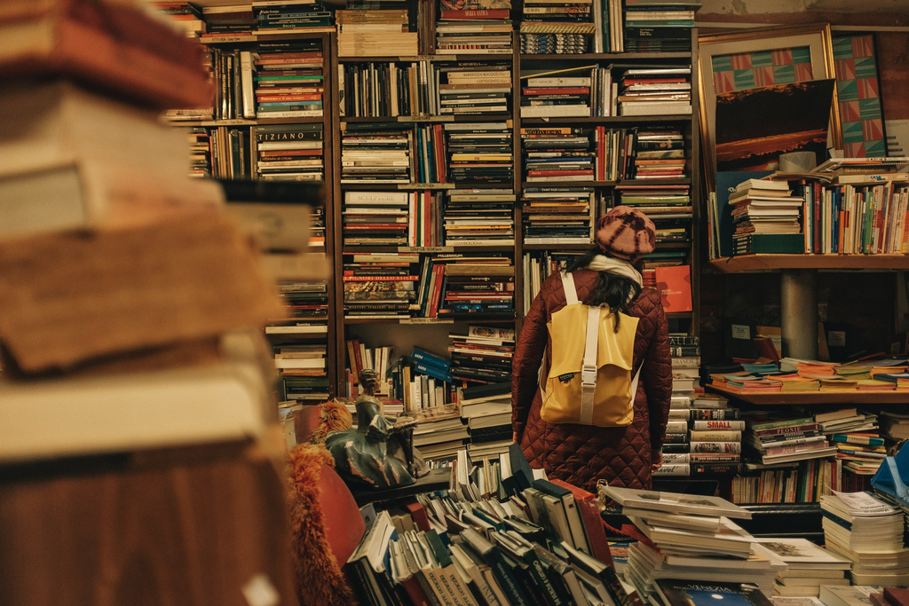

Photo by [Darwin Vegher](https://unsplash.com/@darwiiiin?utm_source=unsplash&utm_medium=referral&utm_content=creditCopyText) on [Unsplash](https://unsplash.com/s/photos/database?utm_source=unsplash&utm_medium=referral&utm_content=creditCopyText)

In this post I will give information about how to connect your database from R, and **+Add**, **Manipulate** data tables using R or SQL codes. I choose **PostgresSQL** as database.

As example data I use [Tidy Tuesday Video Games Dataset](https://github.com/rfordatascience/tidytuesday/tree/master/data/2019/2019-07-30). It contains more than 26K rows. So I filter data frame only 3 developers, **Ubisoft Montreal**, **Valve**, **Square Enix** and create little data table. You can find .xlsx files on my [repo.](https://github.com/serdardindas/postgres_with_r)

### 1)Libraries

```r
library(DBI)        # A database interface for communication between R and relational database management systems
library(RPostgres)  # Interface for 'PostgreSQL
library(dplyr)      # For data manipulation [Best Tool Ever :)]
```

### 2)Connect Postgres Database from R

I already create database in my local Postgres named **VideoGames**. This database has no data tables in it.

Firstly we need to introduce our database to R. To create connection, we define **con** variable.

```r
con <- dbConnect(
  RPostgres::Postgres(), # Call Postgres interface
  host = "localhost",    # Host is where your database hosted. In this example I use my local database
  port = 5432,           # Your database connection port, It defult 5432 for Postgres
  dbname = "VideoGames", # Your database name
  user = "postgres",     # Your Postgres database username
  password = "sanjeon"   # Your Postgres database password
)
```

To check database connection has been established **dbIsValid(con)** can be used. Most of the time we’re going to use **con** argument with database functions.

```r
dbIsValid(con)
```

```
[1] TRUE
```

Now you see [TRUE] that shows we connect VideoGames database with R.

**dbListTables()** list all tables that database have.

```r
dbListTables(con)
```

[output not shown]

### 3)Import Table Into Postgresql

Let’s import our table into VideoGames database. I will use video_games_data as I mentioned before.

```r
video_games_data <- readxl::read_excel("video_games_data.xlsx",
                                       col_types = c("numeric", "text", "text", "text", "numeric"))

video_games_price <- readxl::read_excel("video_games_price.xlsx",
                                       col_types = c("numeric", "text", "numeric"))

dbWriteTable(con, "videogames_data", video_games_data, overwrite=TRUE)
dbWriteTable(con, "videogames_price", video_games_price, overwrite=TRUE)
```

With **dbWriteTable()** function we add our table. As you see in the function there is *overwrite* argument in it. *Overwrite=TRUE* helps you overwrite your table if already exist.

```r
dbListTables(con)
```

[output not shown]

Tables’s fields ->  
**videogames_data:** *number(ID)*, *game*, *release_date*, *developer*, *metascore*  
**videogames_price:** *number(ID)*, *game*, *price*

### 4)Call Tables From Database

```r
videogames_data <-tbl(con,"videogames_data") %>% collect()
```

**ii) With DBI’s dbSendQuery() function**  
**dbSendQuery()** function lets you use SQL queries inside in it. You could take data as you need at the beginning by from database with queries. You have to add extra step convert your query to data frame output with **dbFetch()** like *collect()* in *dplyr*.

```r
videogames_price <- dbSendQuery(con, "SELECT * FROM videogames_price") %>% dbFetch()
```

### 5)Manipulate Data

**i) With Dplyr tbl() function**  
**tbl()** let user dplyr’s manipulation functions such as: *filter*, *select*, *arrange*, *mutate* etc. after in a pipeline. You should not forget **collect** at the end of the pipeline to get your data as data frame.

```r
Higher_Than_80 <- tbl(con, "videogames_data") %>%
                            filter(metascore>=80) %>%
                            group_by(developer) %>%
                            summarise(Games_Count_Higher_Than_80=n()) %>%
                            arrange(desc(Games_Count_Higher_Than_80)) #%>%
                            #collect()
Higher_Than_80
```

```
# Source:     lazy query [?? x 2]
# Database:   postgres [postgres@localhost:5432/VideoGames]
# Ordered by: desc(Games_Count_Higher_Than_80)
  developer        Games_Count_Higher_Than_80
  <chr>                               <int64>
1 Ubisoft Montreal                         17
2 Valve                                    11
3 Square Enix                               2
```

This is the thing you might see *Source lazy query [?? x 2]* I will not give detail about it. But if you want to get any idea about I suggest you to take a look [Vebash Naidoo’s Post](https://sciencificity-blog.netlify.app/posts/2020-12-12-using-the-tidyverse-with-databases/#whats-with-this-lazy-query-were-seeing) that gives me starting point.

Dplyr also has **show_query()** function, helps you convert your dplyr pipelines into SQL queries. This is amazing tool for R users who is SQL-beginner.

```r
tbl(con, "videogames_data") %>%
          filter(metascore>=80) %>%
          group_by(developer) %>%
          summarise(Games_Count_Higher_Than_80=n()) %>%
          arrange(desc(Games_Count_Higher_Than_80)) %>%
          show_query()
```

```
<SQL>
SELECT "developer", COUNT(*) AS "Games_Count_Higher_Than_80"
FROM "videogames_data"
WHERE ("metascore" >= 80.0)
GROUP BY "developer"
ORDER BY "Games_Count_Higher_Than_80" DESC
```

**ii) With DBI dbSendQuery() function**  
As I mentioned before **dbSendQuery()** execute SQL queries. We use *show_query* output inside it. Again **dbFetch()** is here for turning into data frame.

```r
dbFetch(
dbSendQuery(con,
                 'SELECT "developer", COUNT(*) AS "Games_Count_Higher_Than_80"
 FROM "videogames_data"
 WHERE ("metascore" >= 80.0)
 GROUP BY "developer"
 ORDER BY "Games_Count_Higher_Than_80" DESC' )
)
```

```
         developer Games_Count_Higher_Than_80
1 Ubisoft Montreal                         17
2            Valve                         11
3      Square Enix                          2
```

**iii) Import Result Table Into Database**  
It is possible that you can add your new data frame defined in R enviroment into database. *Code chunk we defined Higher_Than_80 data frame we commented #collect() function to show lazy query term.*

```r
Higher_Than_80 <-Higher_Than_80 %>% collect()

dbWriteTable(con, "higherthan_80", Higher_Than_80, overwrite=TRUE)
```

### 6)Add New Data Row to Table

This part we try to add new data input directly into database table.

There is also an alternative way.You can also take database table into R Enviroment, add your new data input in here, and reload your data frame into database again. I believe this could be costly, haven’t try for large data tables yet.

First we define our new input data. I choose Ubisoft Montreal’s *Assasins Creed Valhalla* as an example.

```r
new_input <- data.frame(number= 8000,
           game= "Assassins Creed Valhalla",
           release_date= "Nov 10, 2020",
           developer= "Ubisoft Montreal",
           metascore= 82)
```

| number | game | release_date | developer | metascore |
| --- | --- | --- | --- | --- |
| 8000 | Assassins Creed Valhalla | Nov 10, 2020 | Ubisoft Montreal | 82 |

Lets add this new row of data into **videogames_data** table. We use **dbWriteTable()** again for this process.

```r
dbWriteTable(con, name="videogames_data",
                  new_input,
                  append=TRUE,
                  row.names=FALSE, # drop new_input data rownames
                  overwrite=FALSE)  # prevent from add same data
```

Lets check last 5 row of videogames_data table in database.For this we can use **tail()** function but we get error like: *tail() is not supported by sql*. But **head()** function not give an error like **tail()**. So we arrange data frame with descending order and **head()** it.

```r
tbl(con, "videogames_data") %>% arrange(desc(number)) %>% head(5)
```

```
# Source:     lazy query [?? x 5]
# Database:   postgres [postgres@localhost:5432/VideoGames]
# Ordered by: desc(number)
  number game                       release_date developer   metascore
   <dbl> <chr>                      <chr>        <chr>           <dbl>
1   8000 Assassins Creed Valhalla   Nov 10, 2020 Ubisoft Mo~        82
2   7967 FINAL FANTASY XV WINDOWS ~ Mar 6, 2018  Square Enix         0
3   6795 DRAGON QUEST XI: Echoes o~ Sep 4, 2018  Square Enix         0
4   6247 FINAL FANTASY XV WINDOWS ~ Jun 7, 2018  Square Enix         0
5   6144 Assassins Creed Origins    Oct 26, 2017 Ubisoft Mo~         0
```

we can see Assassins Creed Vahalla in the first row of table (*thanks to arrange(desc())*)

### 7)Delete Data Block or Row From Data Table

This part i give an additional information. While I searching about database operations with R. I curious about how to delete any information from database directly. I find a solution using with **dbExecute()** + **SQL**

To delete data, we added before “Assassins Creed Vahalla” which has ID *number = 8000*

```r
dbExecute(con, 'DELETE from videogames_data WHERE number=8000' )
```

```
[1] 1
```

And check table again

```r
tbl(con, "videogames_data") %>% arrange(desc(number)) %>% head(5)
```

```
# Source:     lazy query [?? x 5]
# Database:   postgres [postgres@localhost:5432/VideoGames]
# Ordered by: desc(number)
  number game                       release_date developer   metascore
   <dbl> <chr>                      <chr>        <chr>           <dbl>
1   7967 FINAL FANTASY XV WINDOWS ~ Mar 6, 2018  Square Enix         0
2   6795 DRAGON QUEST XI: Echoes o~ Sep 4, 2018  Square Enix         0
3   6247 FINAL FANTASY XV WINDOWS ~ Jun 7, 2018  Square Enix         0
4   6144 Assassins Creed Origins    Oct 26, 2017 Ubisoft Mo~         0
5   5979 Tales of Wedding Rings VR  Sep 24, 2018 Square Enix         0
```

You see “Assassins Creed Vahalla” data already deleted. You can use this query style to exclude more than a row, like using **WHERE developer=Valve**

### Conclusion

With this post I try to give brief instructions how to use R for PostgreSQL database operations. I gather some basic usage of R codes from blog post and stackoverflow.

I’m grateful [Vebaash Naidoo](https://twitter.com/Sciencificity) for her [blog posts](https://sciencificity-blog.netlify.app/) that help me to pave way to create this post.

——————————- **This Post Made with** **by** ❤️ ———————————